# BNPP_Wheat_Basic

Celeste Basken

2026-01-27

# BNPP Wheat Biomass

```r
# Loading in data to explore
BNPP <- read.csv("Biomass/BNPP_Wheat_Weights.csv")

BNPP <- BNPP %>%
  mutate(
    Inoculation = factor(Inoculation),
    Polyculture = factor(Polyculture),
    Group = interaction(Inoculation, Polyculture, sep = "_")
  )
```

## Part 1: Pretty basic figures

Clustering without regard to PPT:

- Just a note here: I’m using Biomass_g_pp, which is grams per plant of wheat BNPP.

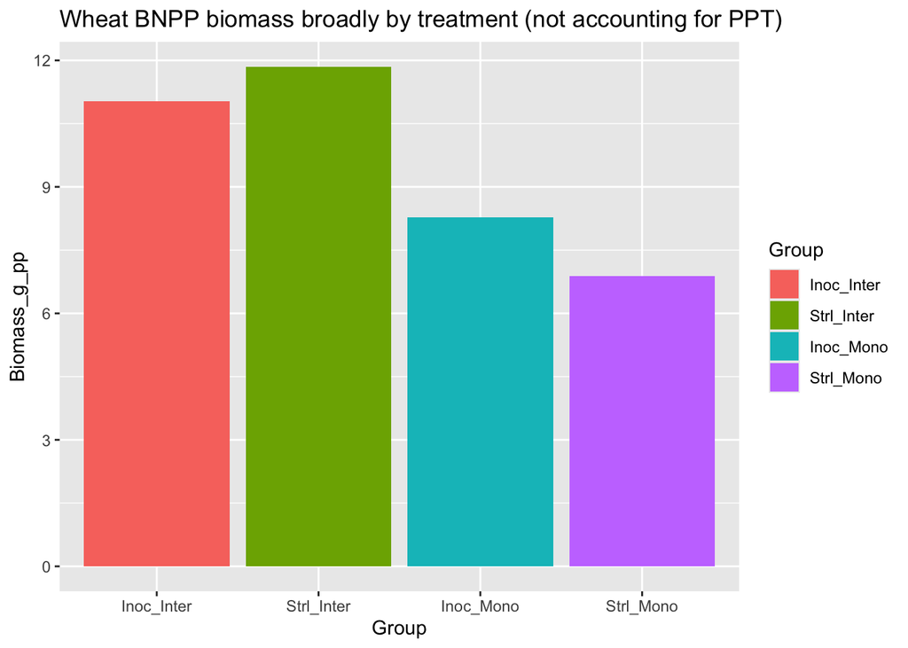

The same data is below, but with each pot plotted so you can see the variation within the treatments:

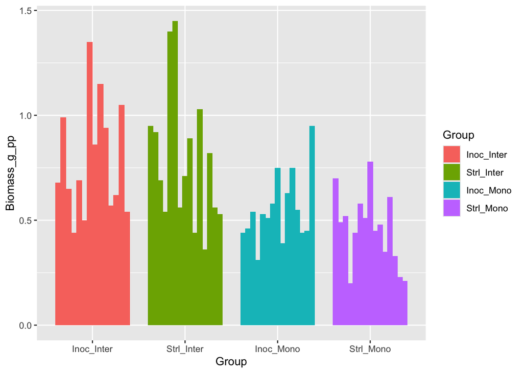

## Part 2: Looking at PPT and what the general behavior is

To begin, here’s what I would EXPECT the graph to look like:

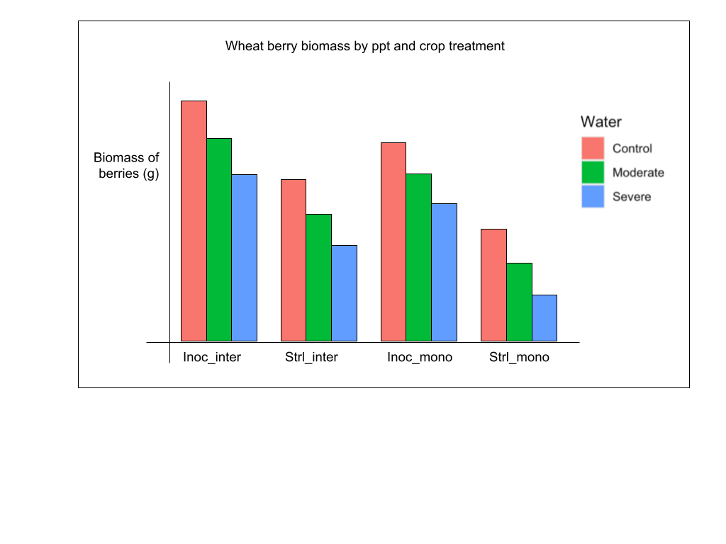

```r
knitr::include_graphics("Biomass/BNPP/expected.png")
```

Here’s the actual figure with the data:

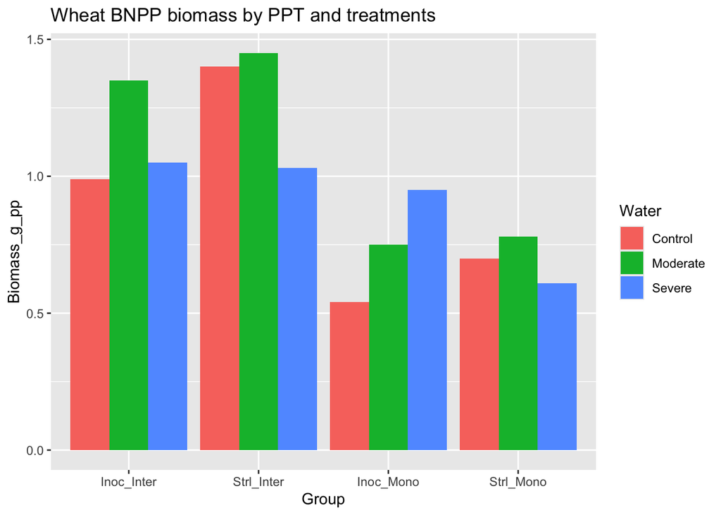

## Analyzing these BNPP biomass trends more in depth

All of the treatments together looking at water: both as a bar graph and boxplot

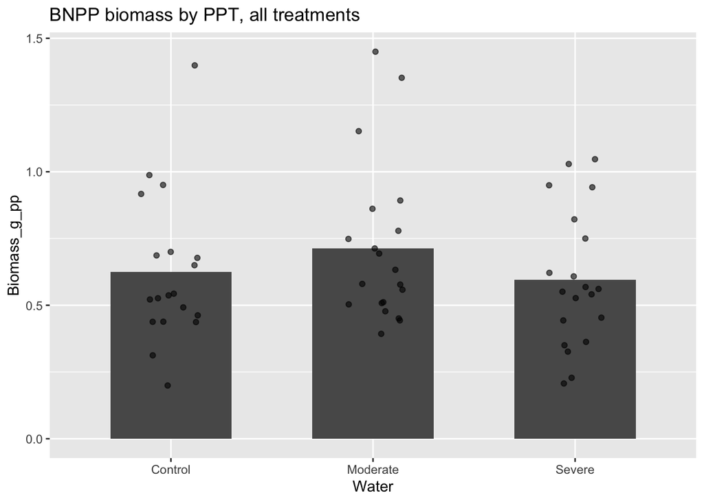

```r
# Bar graph looking at water with the individual points plotted on trop
ggplot(BNPP, aes(x = Water, y = Biomass_g_pp)) +
  stat_summary(fun = mean, geom = "col", width = 0.6) +
  geom_jitter(width = 0.15, alpha = 0.6) +
  ggtitle("BNPP biomass by PPT, all treatments")
```

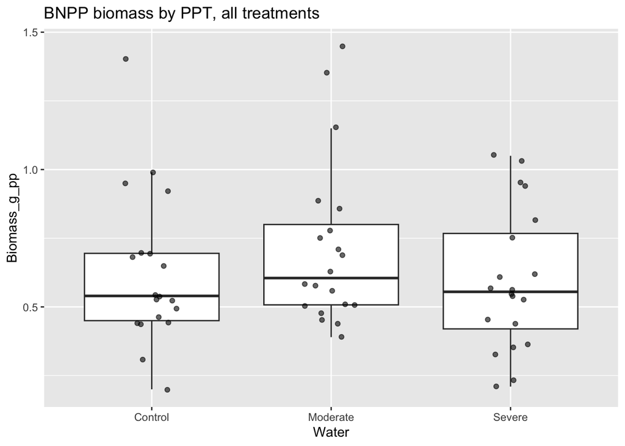

```r
# The same thing (kind of) but as a boxplot with the scattered points

#This code is redundant but good for copy paste later?
BNPP <- BNPP %>%
  mutate(
    Water = factor(Water, levels = c("Control", "Moderate", "Severe"))
  )

# The plot
ggplot(BNPP, aes(x = Water, y = Biomass_g_pp)) +
  geom_boxplot(outlier.shape = NA) +
  geom_jitter(width = 0.15, alpha = 0.6) +
  ggtitle("BNPP biomass by PPT, all treatments")
```

## Focusing on crop diversity: inter vs mono

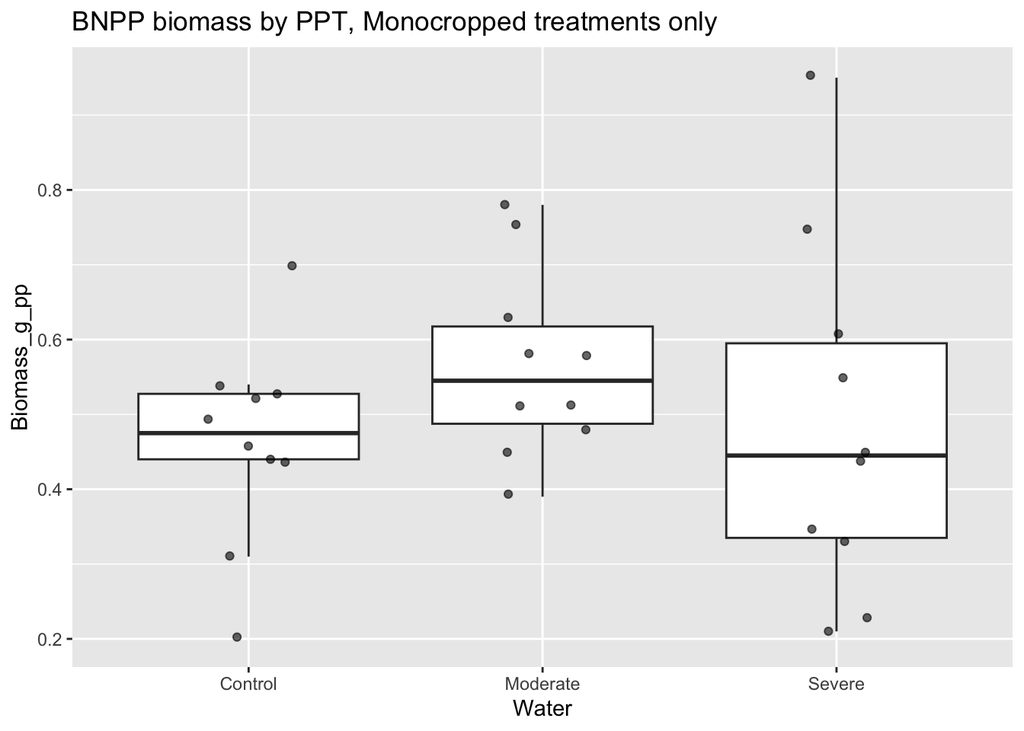

```r
# Looking at just monocropped

BNPP <- BNPP %>%
  mutate(
    Water = factor(Water, levels = c("Control", "Moderate", "Severe")),
    Inoculation = factor(Inoculation),
    Polyculture = factor(Polyculture)
  )

BNPP_inter <- BNPP %>%
  filter(Polyculture == "Mono")

ggplot(BNPP_inter, aes(x = Water, y = Biomass_g_pp)) +
  geom_boxplot(outlier.shape = NA) +
  geom_jitter(width = 0.15, alpha = 0.6) +
  ggtitle("BNPP biomass by PPT, Monocropped treatments only")
```

And looking at intercropped

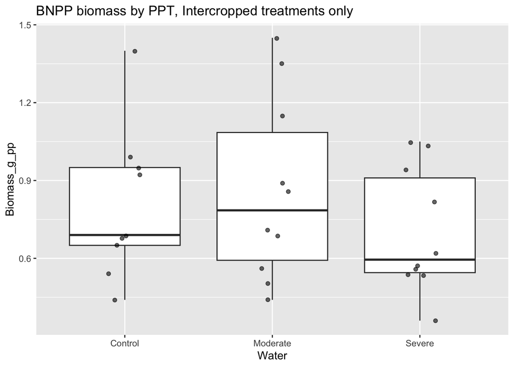

```r
# Looking at just intercropped

BNPP <- BNPP %>%
  mutate(
    Water = factor(Water, levels = c("Control", "Moderate", "Severe")),
    Inoculation = factor(Inoculation),
    Polyculture = factor(Polyculture)
  )

BNPP_inter <- BNPP %>%
  filter(Polyculture == "Inter")

ggplot(BNPP_inter, aes(x = Water, y = Biomass_g_pp)) +
  geom_boxplot(outlier.shape = NA) +
  geom_jitter(width = 0.15, alpha = 0.6) +
  ggtitle("BNPP biomass by PPT, Intercropped treatments only")
```

Let’s see that side by side and broken down by inoculation status as well

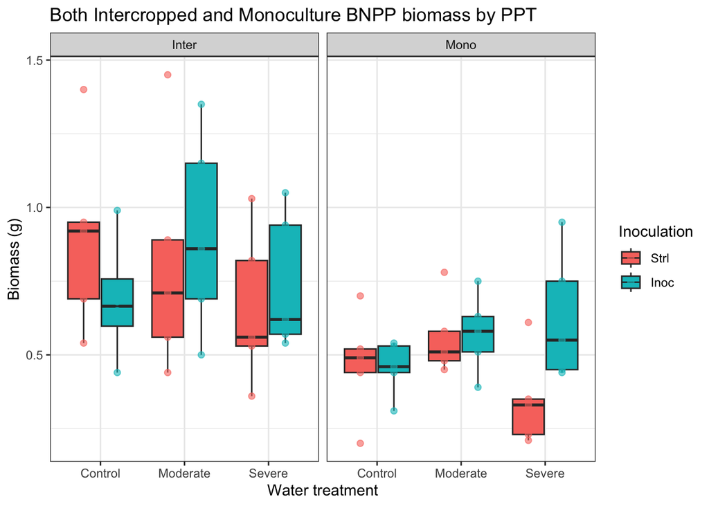

```r
# Splitting it by crop treatment

BNPP <- BNPP %>%
  mutate(
    Water       = factor(Water, levels = c("Control", "Moderate", "Severe")),
    Inoculation = factor(Inoculation, levels = c("Strl", "Inoc")),
    Polyculture = factor(Polyculture, levels = c("Inter", "Mono"))
  )

ggplot(BNPP, aes(x = Water, y = Biomass_g_pp, fill = Inoculation)) +
  geom_boxplot(
    outlier.shape = NA,
    position = position_dodge(width = 0.8)
  ) +
  geom_point(
    aes(color = Inoculation),
    alpha = 0.6,
    size = 1.8,
    position = position_dodge(width = 0.8)
  ) +
  facet_wrap(~ Polyculture) +
  theme_bw() +
  labs(
    x = "Water treatment",
    y = "Biomass (g)"
  ) +
  ggtitle("Both Intercropped and Monoculture BNPP biomass by PPT")
```

## BNPP statistics

To conclude my BNPP work, let’s generate some statistics

Before I begin I want to check some assumptions of a t-test

The boxes shouldn’t have overly long tails or outliers. The residuals should be straight.

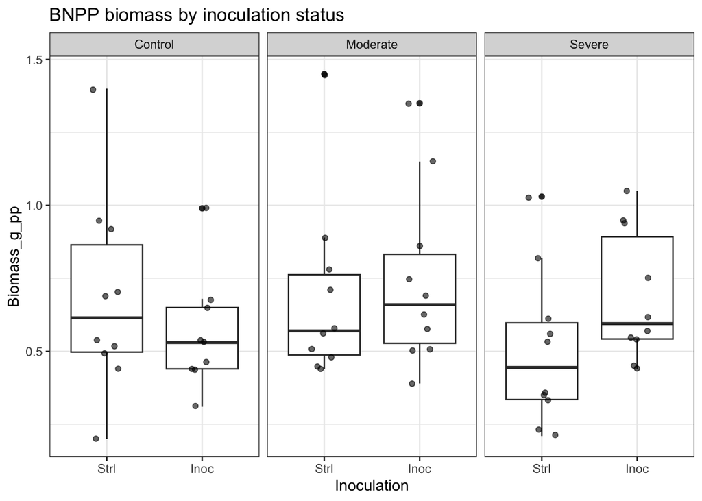

```r
# Check of distributions
ggplot(BNPP, aes(x = Inoculation, y = Biomass_g_pp)) +
  geom_boxplot() +
  geom_jitter(width = 0.15, alpha = 0.6) +
  facet_wrap(~ Water) +
  theme_bw() +
  ggtitle("BNPP biomass by inoculation status")
```

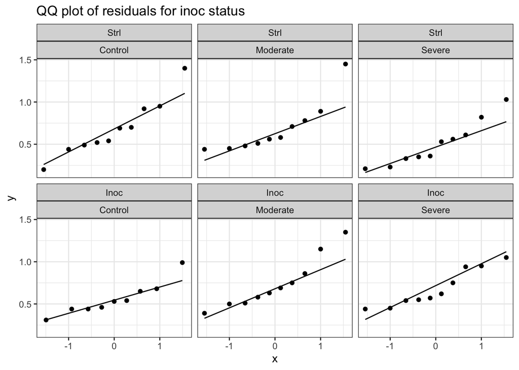

```r
# Q–Q plots of residuals
ggplot(BNPP, aes(sample = Biomass_g_pp)) +
  stat_qq() +
  stat_qq_line() +
  facet_wrap(~ Inoculation + Water) +
  theme_bw() +
  ggtitle("QQ plot of residuals for inoc status")
```

This next section is generating a variety of summary statistics about the data, and then saving them as CSVs.

```r
# Load + clean
BNPP <- BNPP %>%
  mutate(
    Inoculation = factor(Inoculation, levels = c("Strl", "Inoc")),
    Polyculture = factor(Polyculture, levels = c("Mono", "Inter")),
    Water = factor(Water, levels = c("Control", "Moderate", "Severe"))
  ) %>%
  filter(!is.na(Biomass_g_pp))

# Descriptive statistics
desc_stats <- function(x) {
  tibble(
    n      = sum(!is.na(x)),
    mean   = mean(x, na.rm = TRUE),
    sd     = sd(x, na.rm = TRUE),
    se     = sd(x, na.rm = TRUE) / sqrt(sum(!is.na(x))),
    median = median(x, na.rm = TRUE),
    q25    = quantile(x, 0.25, na.rm = TRUE, names = FALSE),
    q75    = quantile(x, 0.75, na.rm = TRUE, names = FALSE),
    iqr    = IQR(x, na.rm = TRUE),
    min    = min(x, na.rm = TRUE),
    max    = max(x, na.rm = TRUE)
  )
}

# Each of the 4 treatments within each Water level
summary_4treat_by_water <- BNPP %>%
  group_by(Water, Inoculation, Polyculture) %>%
  summarise(desc_stats(Biomass_g_pp), .groups = "drop")

# Inoculation only (fold inter/mono together), within each Water
summary_inoc_by_water <- BNPP %>%
  group_by(Water, Inoculation) %>%
  summarise(desc_stats(Biomass_g_pp), .groups = "drop")

# Polyculture only (fold inoc/strl together), within each Water
summary_poly_by_water <- BNPP %>%
  group_by(Water, Polyculture) %>%
  summarise(desc_stats(Biomass_g_pp), .groups = "drop")

# Oerall summaries across Water (all data)
summary_4treat_overall <- BNPP %>%
  group_by(Inoculation, Polyculture) %>%
  summarise(desc_stats(Biomass_g_pp), .groups = "drop")

summary_inoc_overall <- BNPP %>%
  group_by(Inoculation) %>%
  summarise(desc_stats(Biomass_g_pp), .groups = "drop")

summary_poly_overall <- BNPP %>%
  group_by(Polyculture) %>%
  summarise(desc_stats(Biomass_g_pp), .groups = "drop")


# Looking at them as tables
summary_4treat_by_water
```

```
## # A tibble: 12 × 13
##    Water    Inoculation Polyculture     n  mean     sd     se median   q25   q75
##    <fct>    <fct>       <fct>       <int> <dbl>  <dbl>  <dbl>  <dbl> <dbl> <dbl>
##  1 Control  Strl        Mono            5 0.47  0.18   0.0805  0.49  0.44  0.52
##  2 Control  Strl        Inter           5 0.9   0.327  0.146   0.92  0.69  0.95
##  3 Control  Inoc        Mono            5 0.456 0.0924 0.0413  0.46  0.44  0.53
##  4 Control  Inoc        Inter           4 0.69  0.227  0.113   0.665 0.598 0.758
##  5 Moderate Strl        Mono            5 0.56  0.132  0.0591  0.51  0.48  0.58
##  6 Moderate Strl        Inter           5 0.81  0.395  0.177   0.71  0.56  0.89
##  7 Moderate Inoc        Mono            5 0.572 0.134  0.0600  0.58  0.51  0.63
##  8 Moderate Inoc        Inter           5 0.91  0.343  0.153   0.86  0.69  1.15
##  9 Severe   Strl        Mono            5 0.346 0.160  0.0714  0.33  0.23  0.35
## 10 Severe   Strl        Inter           5 0.66  0.264  0.118   0.56  0.53  0.82
## 11 Severe   Inoc        Mono            5 0.628 0.219  0.0979  0.55  0.45  0.75
## 12 Severe   Inoc        Inter           5 0.744 0.234  0.105   0.62  0.57  0.94
## # ℹ 3 more variables: iqr <dbl>, min <dbl>, max <dbl>
```

```r
summary_inoc_by_water
```

```
## # A tibble: 6 × 12
##   Water    Inoculation     n  mean    sd     se median   q25   q75   iqr   min
##   <fct>    <fct>       <int> <dbl> <dbl>  <dbl>  <dbl> <dbl> <dbl> <dbl> <dbl>
## 1 Control  Strl           10 0.685 0.336 0.106   0.615 0.498 0.865 0.368  0.2
## 2 Control  Inoc            9 0.56  0.197 0.0656  0.53  0.44  0.65  0.21   0.31
## 3 Moderate Strl           10 0.685 0.308 0.0973  0.57  0.488 0.762 0.275  0.44
## 4 Moderate Inoc           10 0.741 0.303 0.0959  0.66  0.528 0.832 0.305  0.39
## 5 Severe   Strl           10 0.503 0.264 0.0835  0.445 0.335 0.598 0.263  0.21
## 6 Severe   Inoc           10 0.686 0.222 0.0703  0.595 0.542 0.892 0.35   0.44
## # ℹ 1 more variable: max <dbl>
```

```r
summary_poly_by_water
```

```
## # A tibble: 6 × 12
##   Water    Polyculture     n  mean    sd     se median   q25   q75    iqr   min
##   <fct>    <fct>       <int> <dbl> <dbl>  <dbl>  <dbl> <dbl> <dbl>  <dbl> <dbl>
## 1 Control  Mono           10 0.463 0.135 0.0427  0.475 0.44  0.528 0.0875  0.2
## 2 Control  Inter           9 0.807 0.291 0.0971  0.69  0.65  0.95  0.3     0.44
## 3 Moderate Mono           10 0.566 0.126 0.0398  0.545 0.488 0.618 0.13    0.39
## 4 Moderate Inter          10 0.86  0.353 0.112   0.785 0.592 1.08  0.492   0.44
## 5 Severe   Mono           10 0.487 0.234 0.0740  0.445 0.335 0.595 0.26    0.21
## 6 Severe   Inter          10 0.702 0.240 0.0757  0.595 0.545 0.91  0.365   0.36
## # ℹ 1 more variable: max <dbl>
```

```r
# Saving these as csvs

write.csv(summary_4treat_by_water,
          file.path(("Biomass/BNPP"), "summary_4treat_by_water.csv"),
          row.names = FALSE)

write.csv(summary_inoc_by_water,
          file.path(("Biomass/BNPP"), "summary_inoc_by_water.csv"),
          row.names = FALSE)

write.csv(summary_poly_by_water,
          file.path(("Biomass/BNPP"), "summary_poly_by_water.csv"),
          row.names = FALSE)

write.csv(summary_4treat_overall,
          file.path(("Biomass/BNPP"), "summary_4treat_overall.csv"),
          row.names = FALSE)

write.csv(summary_inoc_overall,
          file.path(("Biomass/BNPP"), "summary_inoc_overall.csv"),
          row.names = FALSE)

write.csv(summary_poly_overall,
          file.path(("Biomass/BNPP"), "summary_poly_overall.csv"),
          row.names = FALSE)
```

## BNPP statistical analysis

I used AI to generate stats. This should be verified for sure!! Especially to make sure I meet the assumptions to even be using these stats.

```r
# These statistics were Chat GPT and should be verified

# P-VALUES: Simple comparisons within each Water ----
# Welch t-tests are robust to unequal variances (default in t.test)

# a) Inoculation effect within each Water (folding Polyculture)
ttest_inoc_within_water <- BNPP %>%
  group_by(Water) %>%
  do(tidy(t.test(Biomass_g_pp ~ Inoculation, data = .))) %>%
  ungroup() %>%
  select(Water, estimate1, estimate2, statistic, p.value, conf.low, conf.high, method)

# b) Polyculture effect within each Water (folding Inoculation)
ttest_poly_within_water <- BNPP %>%
  group_by(Water) %>%
  do(tidy(t.test(Biomass_g_pp ~ Polyculture, data = .))) %>%
  ungroup() %>%
  select(Water, estimate1, estimate2, statistic, p.value, conf.low, conf.high, method)

# ---- 3-way factorial model (lets you test interactions) ----
# If your data are fairly normal-ish, this is a strong default.
fit_aov <- aov(Biomass_g_pp ~ Inoculation * Polyculture * Water, data = BNPP)
aov_table <- broom::tidy(fit_aov)

# ---- Optional: Nonparametric alternatives (in case assumptions are shaky) ----
# Wilcoxon rank-sum within each Water for Inoculation / Polyculture
wilcox_inoc_within_water <- BNPP %>%
  group_by(Water) %>%
  do(tidy(wilcox.test(Biomass_g_pp ~ Inoculation, data = ., exact = FALSE))) %>%
  ungroup() %>%
  select(Water, statistic, p.value, method)

wilcox_poly_within_water <- BNPP %>%
  group_by(Water) %>%
  do(tidy(wilcox.test(Biomass_g_pp ~ Polyculture, data = ., exact = FALSE))) %>%
  ungroup() %>%
  select(Water, statistic, p.value, method)

# Print these

ttest_inoc_within_water
```

```
## # A tibble: 3 × 8
##   Water    estimate1 estimate2 statistic p.value conf.low conf.high method
##   <fct>        <dbl>     <dbl>     <dbl>   <dbl>    <dbl>     <dbl> <chr>
## 1 Control      0.685     0.56      1.00    0.333   -0.142    0.392  Welch Two S…
## 2 Moderate     0.685     0.741    -0.410   0.687   -0.343    0.231  Welch Two S…
## 3 Severe       0.503     0.686    -1.68    0.111   -0.413    0.0468 Welch Two S…
```

```r
ttest_poly_within_water
```

```
## # A tibble: 3 × 8
##   Water    estimate1 estimate2 statistic p.value conf.low conf.high method
##   <fct>        <dbl>     <dbl>     <dbl>   <dbl>    <dbl>     <dbl> <chr>
## 1 Control      0.463     0.807     -3.24 0.00785   -0.577  -0.110   Welch Two S…
## 2 Moderate     0.566     0.86      -2.48 0.0300    -0.554  -0.0340  Welch Two S…
## 3 Severe       0.487     0.702     -2.03 0.0573    -0.437   0.00743 Welch Two S…
```

```r
aov_table
```

```
## # A tibble: 8 × 6
##   term                             df  sumsq meansq statistic    p.value
##   <chr>                         <dbl>  <dbl>  <dbl>     <dbl>      <dbl>
## 1 Inoculation                       1 0.0254 0.0254     0.431  0.515
## 2 Polyculture                       1 1.19   1.19      20.2    0.0000453
## 3 Water                             2 0.145  0.0726     1.23   0.302
## 4 Inoculation:Polyculture           1 0.0343 0.0343     0.580  0.450
## 5 Inoculation:Water                 2 0.213  0.106      1.80   0.176
## 6 Polyculture:Water                 2 0.0363 0.0181     0.307  0.737
## 7 Inoculation:Polyculture:Water     2 0.0670 0.0335     0.568  0.571
## 8 Residuals                        47 2.77   0.0590    NA     NA
```

```r
# Saving as CSV

write.csv(ttest_inoc_within_water,
          file.path(("Biomass/BNPP/Stats"), "ttest_inoc_within_water.csv"),
          row.names = FALSE)

write.csv(ttest_poly_within_water,
          file.path(("Biomass/BNPP/Stats"), "ttest_poly_within_water.csv"),
          row.names = FALSE)

write.csv(aov_table,
          file.path(("Biomass/BNPP/Stats"), "anova_3way_table.csv"),
          row.names = FALSE)

write.csv(wilcox_inoc_within_water,
          file.path(("Biomass/BNPP/Stats"), "wilcox_inoc_within_water.csv"),
          row.names = FALSE)

write.csv(wilcox_poly_within_water,
          file.path(("Biomass/BNPP/Stats"), "wilcox_poly_within_water.csv"),
          row.names = FALSE)
```